# Rice’s whale eDNA WGS

### Reference Bias

`ref_bias.R`

Overall conclusion: Flukeprint samples did not work. Tube juice and bone samples look OK.

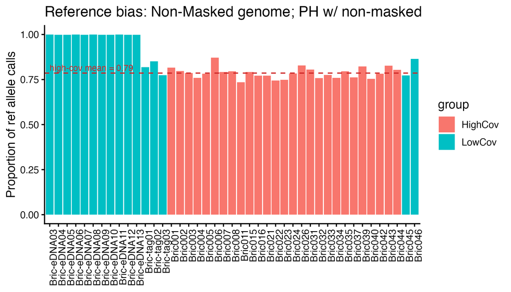

Clearly biased towards the reference allele. 100%!

Solution: Mask the reference genome at known SNPs, from the RW preprint. Then re-align to this. In theory, this should help.

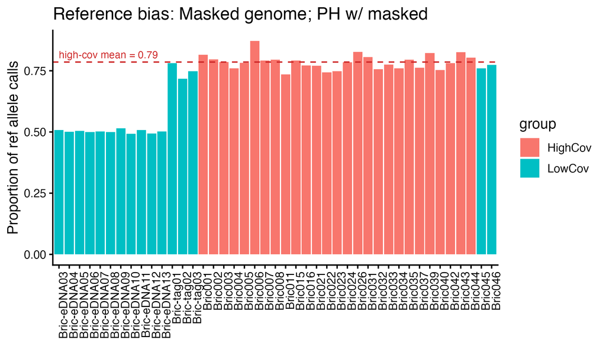

Now they’re 50%. This suggests the SNPs are being randomly called and are not real.

#### use historical dna approach

haven’t done this yet, need to redo it. PopGLen_historical